fossil

# PROSPECTR disease-gene ranking, dug back up.

35 results: 0 exact, 6 agree, 15 partly agree, 1 inconclusive, 6 differ, 7 not attempted. PROSPECTR's Perl scorer is lost, but its training and test sets survive in the Wayback Machine. Run on them, the paper's own tree gives Table 3's training accuracy (67.2% against 67%) and Fig. 3A's curve.

See every result

## Fig. 1

Fig. 1. Histograms of six features in disease genes (OMIM, grey) and control genes (blue): gene length, protein length, mouse BRH identity, mouse Ka, exons and 3' UTR length. Ours: the archived 2006 training set (1,080 + 1,080 genes).

Partly agrees

Published

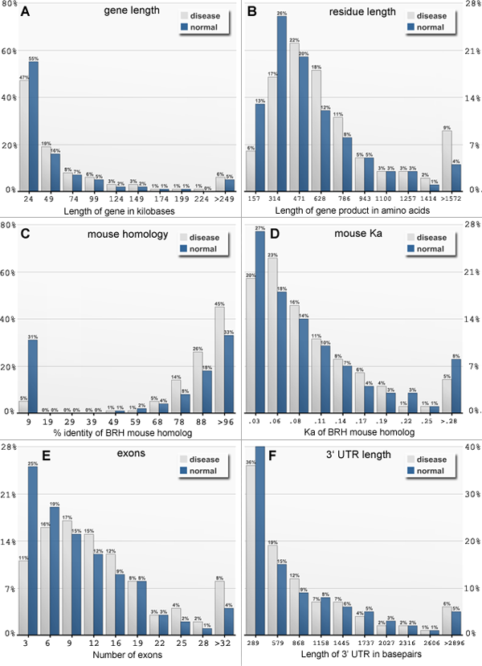

Our run

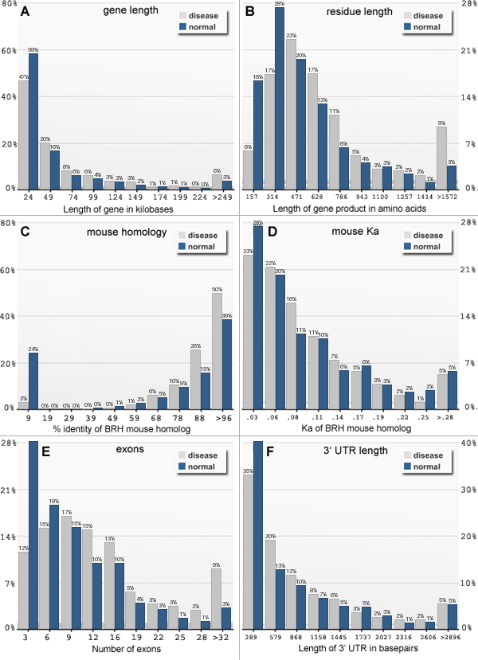

**Fig. 1A, gene length histograms (bar labels)**

13 of 20 values, Partly agrees

**Fig. 1B, protein length histograms (bar labels)**

10 of 20 values, Partly agrees

**Fig. 1C, mouse BRH % identity histograms (bar labels)**

10 of 20 values, Partly agrees

**Fig. 1D, mouse Ka histograms (bar labels)**

6 of 20 values, Partly agrees

**Fig. 1E, number of exons histograms (bar labels)**

8 of 20 values, Partly agrees

**Fig. 1F, 3' UTR length histograms (bar labels)**

7 of 19 values, Partly agrees

The shapes come back; single bars differ by a few points because the archived training set is not the paper's gene set (1,080 controls, not ~18,000; a 2006 Ensembl build).

## Fig. 2

Fig. 2. PROSPECTR's 15-rule alternating decision tree. Ours: the tree Weka 3.4.3 builds with the download page's recipe on the archived training set, as Weka prints it.

Partly agrees

Published

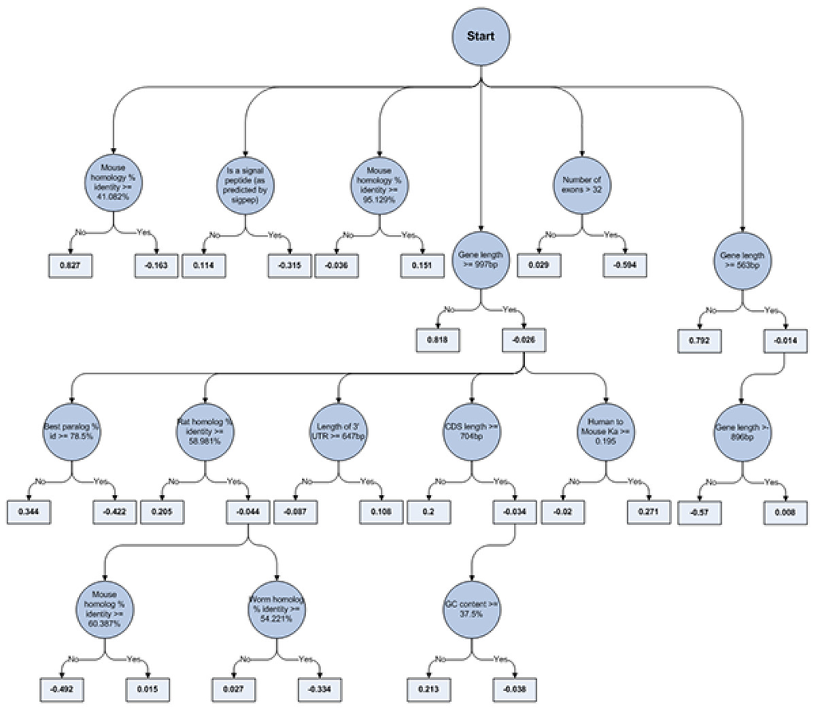

Our run

[figure not shown]

**Fig. 2, the 15-rule alternating decision tree**

5 of 59 values, Partly agrees

Retrained on the archived training set, the recipe puts rules on mouse identity, signal peptide, gene length and exon number at the root, as Figure 2 does, with other thresholds and values (exons > 31 against > 32); the other 11 rules differ. The archived sets are not the paper's: the PROSPECTR site's ARFFs, first captured on 2006-09-30, hold 1,080 + 1,080, 713 + 713 and 50 + 50 genes (the paper: 1,084 + 1,084, 675 + 675 and 54 + 54) and 64 features from a later Ensembl build (Table 1 lists 23), with no gene IDs.

## Fig. 3

Fig. 3. ROC curves of the classifier on the training set (A), the HGMD test set (B) and the oligogenic test set (C). Ours: the published tree on the archived sets, drawn as Weka draws them.

Inconclusive

Published

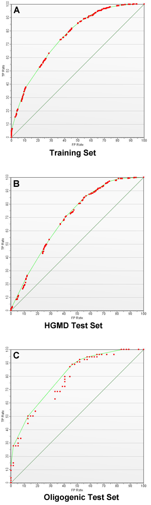

Our run

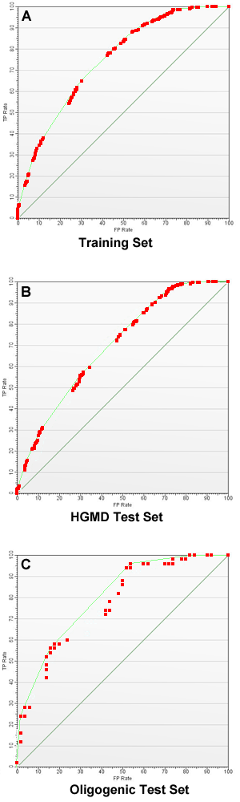

**Fig. 3A, ROC curve, training set (the published tree on the archived set)**

92.6% within 2 px, Agrees

**Fig. 3B, ROC curve, HGMD test set (the published tree on the archived set)**

52.5% within 2 px, Inconclusive

**Fig. 3C, ROC curve, oligogenic test set (the published tree on the archived set)**

62.4% within 2 px, Partly agrees

The pixel score cannot confirm this panel: ours scores 0.52 and two controls score higher (the retrained tree 0.62, ours shifted by +0.02 in FP rate 0.61). Only the AUC agrees (0.693 against Table 3's 0.69; the published points read back give 0.692). The archived HGMD set has 713 + 713 genes, the paper's 675 + 675. Same shape and hull; the points sit on another grid because the archived oligogenic set has 50 + 50 genes (steps of 2%), the paper's 54 + 54 (1.85%). AUC 0.767 against Table 3's 0.76 (the published points read back give 0.770).

## Every result

Every figure, table and claim of the paper. Values match when they are within half a unit of the last printed digit. The archived sets are a 2006 version of the paper's sets, so most values cannot match exactly.

Result

Verdict

Measure

Why

Table 1 (the feature set)

Not attempted

Table 1 lists the 23 features offered to Weka and their sources; it has no result to recompute.

Table 2, medians and tests, disease against control genes

Partly agrees

10 of 21 values

- gene_length_kb: control median: paper 19, ours **16.337**
- gene_length_kb: disease median: paper 27, ours **27.265**
- gene_length_kb: P < 0.001: paper yes, ours **yes**
- cdna_length_bp: control median: paper 2126, ours **1887**
- cdna_length_bp: disease median: paper 2442, ours **2390**
- cdna_length_bp: P < 0.001: paper yes, ours **yes**
- protein_length_aa: control median: paper 383, ours **338**
- protein_length_aa: disease median: paper 494, ours **492**
- protein_length_aa: P < 0.001: paper yes, ours **yes**
- utr3_length_bp: control median: paper 446, ours **336**
- utr3_length_bp: disease median: paper 488, ours **469.5**
- utr3_length_bp: P < 0.01: paper yes, ours **yes**
- exons: control median: paper 8, ours **6**
- exons: disease median: paper 10, ours **10**
- exons: P < 0.001: paper yes, ours **yes**
- mouse_brh_identity_pct: control median: paper 80, ours **81**
- mouse_brh_identity_pct: disease median: paper 87, ours **87**
- mouse_brh_identity_pct: P < 0.001: paper yes, ours **yes**
- signal_peptide_pct: control: paper 17, ours **15.648**
- signal_peptide_pct: disease: paper 35, ours **35.741**
- signal_peptide_pct: P < 0.0001: paper yes, ours **yes**

Table 2, distance to the neighbouring gene and 5' CpG islands

Not attempted

The archived sets have neither feature, and without gene IDs they cannot be rebuilt for the same genes.

Fig. 1A, gene length histograms (bar labels)

Partly agrees

13 of 20 values

The shapes come back; single bars differ by a few points because the archived training set is not the paper's gene set (1,080 controls, not ~18,000; a 2006 Ensembl build).

Fig. 1B, protein length histograms (bar labels)

Partly agrees

10 of 20 values

- disease, bar 157: paper 6, ours **6**
- disease, bar 314: paper 17, ours **17**
- disease, bar 471: paper 22, ours **23**
- disease, bar 628: paper 18, ours **17**
- disease, bar 786: paper 11, ours **11**
- disease, bar 943: paper 5, ours **5**
- disease, bar 1100: paper 3, ours **3**
- disease, bar 1257: paper 3, ours **2**
- disease, bar 1414: paper 2, ours **2**
- disease, bar >1572: paper 9, ours **9**
- normal, bar 157: paper 13, ours **16**
- normal, bar 314: paper 26, ours **28**
- normal, bar 471: paper 20, ours **20**
- normal, bar 628: paper 12, ours **13**
- normal, bar 786: paper 8, ours **6**
- normal, bar 943: paper 5, ours **4**
- normal, bar 1100: paper 3, ours **3**
- normal, bar 1257: paper 3, ours **2**
- normal, bar 1414: paper 1, ours **1**
- normal, bar >1572: paper 4, ours **3**

The shapes come back; single bars differ by a few points because the archived training set is not the paper's gene set (1,080 controls, not ~18,000; a 2006 Ensembl build).

Fig. 1C, mouse BRH % identity histograms (bar labels)

Partly agrees

10 of 20 values

- disease, bar 9: paper 5, ours **3**
- disease, bar 19: paper 0, ours **0**
- disease, bar 29: paper 0, ours **0**
- disease, bar 39: paper 0, ours **0**
- disease, bar 49: paper 1, ours **0**
- disease, bar 59: paper 1, ours **1**
- disease, bar 68: paper 5, ours **6**
- disease, bar 78: paper 14, ours **10**
- disease, bar 88: paper 26, ours **26**
- disease, bar >96: paper 45, ours **50**
- normal, bar 9: paper 31, ours **24**
- normal, bar 19: paper 0, ours **0**
- normal, bar 29: paper 0, ours **0**
- normal, bar 39: paper 0, ours **0**
- normal, bar 49: paper 1, ours **1**
- normal, bar 59: paper 2, ours **2**
- normal, bar 68: paper 4, ours **5**
- normal, bar 78: paper 8, ours **9**
- normal, bar 88: paper 18, ours **15**
- normal, bar >96: paper 33, ours **39**

The shapes come back; single bars differ by a few points because the archived training set is not the paper's gene set (1,080 controls, not ~18,000; a 2006 Ensembl build).

Fig. 1D, mouse Ka histograms (bar labels)

Partly agrees

6 of 20 values

- disease, bar .03: paper 20, ours **23**
- disease, bar .06: paper 23, ours **22**
- disease, bar .08: paper 16, ours **16**
- disease, bar .11: paper 11, ours **11**
- disease, bar .14: paper 8, ours **7**
- disease, bar .17: paper 6, ours **5**
- disease, bar .19: paper 4, ours **3**
- disease, bar .22: paper 1, ours **2**
- disease, bar .25: paper 1, ours **1**
- disease, bar >.28: paper 5, ours **5**
- normal, bar .03: paper 27, ours **28**
- normal, bar .06: paper 18, ours **20**
- normal, bar .08: paper 14, ours **11**
- normal, bar .11: paper 10, ours **10**
- normal, bar .14: paper 7, ours **6**
- normal, bar .17: paper 4, ours **6**
- normal, bar .19: paper 3, ours **3**
- normal, bar .22: paper 3, ours **2**
- normal, bar .25: paper 1, ours **2**
- normal, bar >.28: paper 8, ours **5**

The shapes come back; single bars differ by a few points because the archived training set is not the paper's gene set (1,080 controls, not ~18,000; a 2006 Ensembl build).

Fig. 1E, number of exons histograms (bar labels)

Partly agrees

8 of 20 values

- disease, bar 3: paper 11, ours **12**
- disease, bar 6: paper 16, ours **15**
- disease, bar 9: paper 17, ours **17**
- disease, bar 12: paper 15, ours **15**
- disease, bar 16: paper 12, ours **13**
- disease, bar 19: paper 8, ours **5**
- disease, bar 22: paper 3, ours **3**
- disease, bar 25: paper 4, ours **3**
- disease, bar 28: paper 2, ours **2**
- disease, bar >32: paper 8, ours **9**
- normal, bar 3: paper 25, ours **30**
- normal, bar 6: paper 19, ours **19**
- normal, bar 9: paper 15, ours **15**
- normal, bar 12: paper 12, ours **10**
- normal, bar 16: paper 9, ours **10**
- normal, bar 19: paper 8, ours **4**
- normal, bar 22: paper 3, ours **3**
- normal, bar 25: paper 2, ours **1**
- normal, bar 28: paper 1, ours **1**
- normal, bar >32: paper 4, ours **3**

The shapes come back; single bars differ by a few points because the archived training set is not the paper's gene set (1,080 controls, not ~18,000; a 2006 Ensembl build).

Fig. 1F, 3' UTR length histograms (bar labels)

Partly agrees

7 of 19 values

- disease, bar 289: paper 36, ours **35**
- disease, bar 579: paper 19, ours **20**
- disease, bar 868: paper 12, ours **12**
- disease, bar 1158: paper 7, ours **8**
- disease, bar 1445: paper 7, ours **6**
- disease, bar 1737: paper 4, ours **3**
- disease, bar 2027: paper 2, ours **2**
- disease, bar 2316: paper 2, ours **2**
- disease, bar 2606: paper 1, ours **2**
- disease, bar >2896: paper 6, ours **5**
- normal, bar 579: paper 15, ours **13**
- normal, bar 868: paper 9, ours **10**
- normal, bar 1158: paper 8, ours **7**
- normal, bar 1445: paper 6, ours **5**
- normal, bar 1737: paper 5, ours **5**
- normal, bar 2027: paper 3, ours **3**
- normal, bar 2316: paper 2, ours **1**
- normal, bar 2606: paper 1, ours **1**
- normal, bar >2896: paper 5, ours **5**

The shapes come back; single bars differ by a few points because the archived training set is not the paper's gene set (1,080 controls, not ~18,000; a 2006 Ensembl build).

Fig. 2, the 15-rule alternating decision tree

Partly agrees

5 of 59 values

- rule 1 (Mouse homology % identity >= 41.082%): feature in the same place: paper yes, ours **yes**
- rule 1 (Mouse homology % identity >= 41.082%): threshold: paper 41.082, ours **37.5**
- rule 1 (Mouse homology % identity >= 41.082%): value if no: paper 0.827, ours **1.031**
- rule 1 (Mouse homology % identity >= 41.082%): value if yes: paper -0.163, ours **-0.13**
- rule 2 (Is a signal peptide (as predicted by sigpep)): feature in the same place: paper yes, ours **yes**
- rule 2 (Is a signal peptide (as predicted by sigpep)): value if no: paper 0.114, ours **0.132**
- rule 2 (Is a signal peptide (as predicted by sigpep)): value if yes: paper -0.315, ours **-0.373**
- rule 3 (Mouse homology % identity >= 95.129%): feature in the same place: paper yes, ours **no**
- rule 3 (Mouse homology % identity >= 95.129%): threshold: paper 95.129, ours **absent**
- rule 3 (Mouse homology % identity >= 95.129%): value if no: paper -0.036, ours **absent**
- rule 3 (Mouse homology % identity >= 95.129%): value if yes: paper 0.151, ours **absent**
- rule 4 (Number of exons > 32): feature in the same place: paper yes, ours **yes**
- rule 4 (Number of exons > 32): threshold: paper 32, ours **31**
- rule 4 (Number of exons > 32): value if no: paper 0.029, ours **0.028**
- rule 4 (Number of exons > 32): value if yes: paper -0.594, ours **-0.528**
- rule 5 (Gene length >= 997bp): feature in the same place: paper yes, ours **yes**
- rule 5 (Gene length >= 997bp): threshold: paper 997, ours **996.5**
- rule 5 (Gene length >= 997bp): value if no: paper 0.818, ours **0.936**
- rule 5 (Gene length >= 997bp): value if yes: paper -0.026, ours **-0.029**
- rule 6 (Gene length >= 563bp): feature in the same place: paper yes, ours **no**
- rule 6 (Gene length >= 563bp): threshold: paper 563, ours **absent**
- rule 6 (Gene length >= 563bp): value if no: paper 0.792, ours **absent**
- rule 6 (Gene length >= 563bp): value if yes: paper -0.014, ours **absent**
- rule 7 (Best paralog % id >= 78.5%): feature in the same place: paper yes, ours **no**
- rule 7 (Best paralog % id >= 78.5%): threshold: paper 78.5, ours **absent**
- rule 7 (Best paralog % id >= 78.5%): value if no: paper 0.344, ours **absent**
- rule 7 (Best paralog % id >= 78.5%): value if yes: paper -0.422, ours **absent**
- rule 8 (Rat homolog % identity >= 58.981%): feature in the same place: paper yes, ours **no**
- rule 8 (Rat homolog % identity >= 58.981%): threshold: paper 58.981, ours **absent**
- rule 8 (Rat homolog % identity >= 58.981%): value if no: paper 0.205, ours **absent**
- rule 8 (Rat homolog % identity >= 58.981%): value if yes: paper -0.044, ours **absent**
- rule 9 (Length of 3' UTR >= 647bp): feature in the same place: paper yes, ours **no**
- rule 9 (Length of 3' UTR >= 647bp): threshold: paper 647, ours **absent**
- rule 9 (Length of 3' UTR >= 647bp): value if no: paper -0.087, ours **absent**
- rule 9 (Length of 3' UTR >= 647bp): value if yes: paper 0.108, ours **absent**
- rule 10 (CDS length >= 704bp): feature in the same place: paper yes, ours **no**
- rule 10 (CDS length >= 704bp): threshold: paper 704, ours **absent**
- rule 10 (CDS length >= 704bp): value if no: paper 0.2, ours **absent**
- rule 10 (CDS length >= 704bp): value if yes: paper -0.034, ours **absent**
- rule 11 (Human to Mouse Ka >= 0.195): feature in the same place: paper yes, ours **no**
- rule 11 (Human to Mouse Ka >= 0.195): threshold: paper 0.195, ours **absent**
- rule 11 (Human to Mouse Ka >= 0.195): value if no: paper -0.02, ours **absent**
- rule 11 (Human to Mouse Ka >= 0.195): value if yes: paper 0.271, ours **absent**
- rule 12 (Mouse homolog % identity >= 60.387%): feature in the same place: paper yes, ours **no**
- rule 12 (Mouse homolog % identity >= 60.387%): threshold: paper 60.387, ours **absent**
- rule 12 (Mouse homolog % identity >= 60.387%): value if no: paper -0.492, ours **absent**
- rule 12 (Mouse homolog % identity >= 60.387%): value if yes: paper 0.015, ours **absent**
- rule 13 (Worm homolog % identity >= 54.221%): feature in the same place: paper yes, ours **no**
- rule 13 (Worm homolog % identity >= 54.221%): threshold: paper 54.221, ours **absent**
- rule 13 (Worm homolog % identity >= 54.221%): value if no: paper 0.027, ours **absent**
- rule 13 (Worm homolog % identity >= 54.221%): value if yes: paper -0.334, ours **absent**
- rule 14 (GC content >= 37.5%): feature in the same place: paper yes, ours **no**
- rule 14 (GC content >= 37.5%): threshold: paper 37.5, ours **absent**
- rule 14 (GC content >= 37.5%): value if no: paper 0.213, ours **absent**
- rule 14 (GC content >= 37.5%): value if yes: paper -0.038, ours **absent**
- rule 15 (Gene length >- 896bp (printed so; read as >=)): feature in the same place: paper yes, ours **no**
- rule 15 (Gene length >- 896bp (printed so; read as >=)): threshold: paper 896, ours **absent**
- rule 15 (Gene length >- 896bp (printed so; read as >=)): value if no: paper -0.57, ours **absent**
- rule 15 (Gene length >- 896bp (printed so; read as >=)): value if yes: paper 0.008, ours **absent**

Retrained on the archived training set, the recipe puts rules on mouse identity, signal peptide, gene length and exon number at the root, as Figure 2 does, with other thresholds and values (exons > 31 against > 32); the other 11 rules differ. The archived sets are not the paper's: the PROSPECTR site's ARFFs, first captured on 2006-09-30, hold 1,080 + 1,080, 713 + 713 and 50 + 50 genes (the paper: 1,084 + 1,084, 675 + 675 and 54 + 54) and 64 features from a later Ensembl build (Table 1 lists 23), with no gene IDs.

Text: Spearman correlations of gene size with exon number and 3' UTR length

Differs

0 of 2 values

- gene length and number of exons: paper 0.71, ours **0.7021**
- gene length and 3' UTR length: paper 0.35, ours **0.3862**

0.70 and 0.39 on the archived training set against 0.71 and 0.35; the paper does not say on which genes it computed them, and the archived genes are not its genes.

Text: Spearman correlation of gene size with the distance to the nearest gene (0.69)

Not attempted

The archived sets have no distance feature.

Table 3, training set (the published tree on the archived set), with the text's rates

Partly agrees

1 of 6 values

- accuracy (%): paper 67, ours **67.1759**
- precision (%): paper 65, ours **63.5699**
- recall (%): paper 77, ours **80.463**
- AUC: paper 0.75, ours **0.744459**
- kappa: paper 0.35, ours **0.343519**
- text: controls called disease (%): paper 42, ours **46.1111**

The published tree on the archived sets gives accuracy, AUC and kappa close to Table 3 but calls more genes disease (higher recall, more false positives). The archived sets are not the paper's: the PROSPECTR site's ARFFs, first captured on 2006-09-30, hold 1,080 + 1,080, 713 + 713 and 50 + 50 genes (the paper: 1,084 + 1,084, 675 + 675 and 54 + 54) and 64 features from a later Ensembl build (Table 1 lists 23), with no gene IDs.

Table 3, HGMD test set (the published tree on the archived set), with the text's counts

Partly agrees

1 of 8 values

- accuracy (%): paper 64.5, ours **63.0435**
- precision (%): paper 63, ours **60.1528**
- recall (%): paper 71, ours **77.2791**
- AUC: paper 0.69, ours **0.692546**
- kappa: paper 0.29, ours **0.26087**
- text: controls called disease (%): paper 42, ours **51.1921**
- text: disease genes found (n): paper 478, ours **551**
- text: controls called disease (n): paper 282, ours **365**

The published tree on the archived sets gives accuracy, AUC and kappa close to Table 3 but calls more genes disease (higher recall, more false positives). The archived sets are not the paper's: the PROSPECTR site's ARFFs, first captured on 2006-09-30, hold 1,080 + 1,080, 713 + 713 and 50 + 50 genes (the paper: 1,084 + 1,084, 675 + 675 and 54 + 54) and 64 features from a later Ensembl build (Table 1 lists 23), with no gene IDs.

Table 3, oligogenic test set (the published tree on the archived set), with the text's counts

Partly agrees

2 of 8 values

- accuracy (%): paper 65, ours **67**
- precision (%): paper 63, ours **63.9344**
- recall (%): paper 72, ours **78**
- AUC: paper 0.76, ours **0.7668**
- kappa: paper 0.31, ours **0.34**
- text: controls called disease (%): paper 41, ours **44**
- text: disease genes found (n): paper 39, ours **39**
- text: controls called disease (n): paper 22, ours **22**

The published tree on the archived sets gives accuracy, AUC and kappa close to Table 3 but calls more genes disease (higher recall, more false positives). The archived sets are not the paper's: the PROSPECTR site's ARFFs, first captured on 2006-09-30, hold 1,080 + 1,080, 713 + 713 and 50 + 50 genes (the paper: 1,084 + 1,084, 675 + 675 and 54 + 54) and 64 features from a later Ensembl build (Table 1 lists 23), with no gene IDs. On the oligogenic set it finds 39 disease genes and calls 22 controls disease, the counts the text gives, but of 50 + 50 genes, not 54 + 54.

Table 3, 10-fold cross-validation (retrained, Weka's folds), with the text's rates

Differs

0 of 6 values

- accuracy (%): paper 63, ours **66.6204**
- precision (%): paper 62, ours **65.1222**
- recall (%): paper 70, ours **71.5741**
- AUC: paper 0.70, ours **0.740306**
- kappa: paper 0.27, ours **0.332407**
- text: controls called disease (%): paper 43, ours **38.3333**

Cross-validation on the archived training set gives 67% accuracy (63% in the paper), AUC 0.74 (0.70) and kappa 0.33 (0.27): the archived features separate the classes better than the paper's did. The archived sets are not the paper's: the PROSPECTR site's ARFFs, first captured on 2006-09-30, hold 1,080 + 1,080, 713 + 713 and 50 + 50 genes (the paper: 1,084 + 1,084, 675 + 675 and 54 + 54) and 64 features from a later Ensembl build (Table 1 lists 23), with no gene IDs.

Table 3, training set, tree retrained with the download page's recipe

Differs

0 of 6 values

- accuracy (%): paper 67, ours **70.7407**
- precision (%): paper 65, ours **69.788**
- recall (%): paper 77, ours **73.1481**
- AUC: paper 0.75, ours **0.788664**
- kappa: paper 0.35, ours **0.414815**
- text: controls called disease (%): paper 42, ours **31.6667**

The retrained tree is another tree (Fig. 2 item), so its rates differ; it fits the archived training set better than the paper's tree fit its own. The archived sets are not the paper's: the PROSPECTR site's ARFFs, first captured on 2006-09-30, hold 1,080 + 1,080, 713 + 713 and 50 + 50 genes (the paper: 1,084 + 1,084, 675 + 675 and 54 + 54) and 64 features from a later Ensembl build (Table 1 lists 23), with no gene IDs.

Table 3, HGMD test set, tree retrained with the download page's recipe

Differs

0 of 8 values

- accuracy (%): paper 64.5, ours **64.1655**
- precision (%): paper 63, ours **63.5753**
- recall (%): paper 71, ours **66.3394**
- AUC: paper 0.69, ours **0.699137**
- kappa: paper 0.29, ours **0.28331**
- text: controls called disease (%): paper 42, ours **38.0084**
- text: disease genes found (n): paper 478, ours **473**
- text: controls called disease (n): paper 282, ours **271**

The retrained tree is another tree (Fig. 2 item), so its rates differ; it fits the archived training set better than the paper's tree fit its own. The archived sets are not the paper's: the PROSPECTR site's ARFFs, first captured on 2006-09-30, hold 1,080 + 1,080, 713 + 713 and 50 + 50 genes (the paper: 1,084 + 1,084, 675 + 675 and 54 + 54) and 64 features from a later Ensembl build (Table 1 lists 23), with no gene IDs.

Table 3, oligogenic test set, tree retrained with the download page's recipe

Partly agrees

1 of 8 values

- accuracy (%): paper 65, ours **70**
- precision (%): paper 63, ours **69.2308**
- recall (%): paper 72, ours **72**
- AUC: paper 0.76, ours **0.7994**
- kappa: paper 0.31, ours **0.4**
- text: controls called disease (%): paper 41, ours **32**
- text: disease genes found (n): paper 39, ours **36**
- text: controls called disease (n): paper 22, ours **16**

The retrained tree is another tree (Fig. 2 item), so its rates differ; it fits the archived training set better than the paper's tree fit its own. The archived sets are not the paper's: the PROSPECTR site's ARFFs, first captured on 2006-09-30, hold 1,080 + 1,080, 713 + 713 and 50 + 50 genes (the paper: 1,084 + 1,084, 675 + 675 and 54 + 54) and 64 features from a later Ensembl build (Table 1 lists 23), with no gene IDs.

Fig. 3A, ROC curve, training set (the published tree on the archived set)

Agrees

92.6% within 2 px

Fig. 3B, ROC curve, HGMD test set (the published tree on the archived set)

Inconclusive

52.5% within 2 px

The pixel score cannot confirm this panel: ours scores 0.52 and two controls score higher (the retrained tree 0.62, ours shifted by +0.02 in FP rate 0.61). Only the AUC agrees (0.693 against Table 3's 0.69; the published points read back give 0.692). The archived HGMD set has 713 + 713 genes, the paper's 675 + 675.

Fig. 3C, ROC curve, oligogenic test set (the published tree on the archived set)

Partly agrees

62.4% within 2 px

Same shape and hull; the points sit on another grid because the archived oligogenic set has 50 + 50 genes (steps of 2%), the paper's 54 + 54 (1.85%). AUC 0.767 against Table 3's 0.76 (the published points read back give 0.770).

Table 4, share of each feature in the score of genes called disease (published tree)

Partly agrees

5 of 11 values

- Signal peptide (%): paper 23, ours **23.286**
- Mouse homolog % identity (%): paper 21, ours **22.87**
- Length of 3' UTR (%): paper 12, ours **12.879**
- Number of exons (%): paper 7, ours **7.186**
- Rat homolog % identity (%): paper 7, ours **7.002**
- Worm homolog % identity (%): paper 6, ours **6.506**
- GC (%): paper 6, ours **6.316**
- CDS length (%): paper 5, ours **5.869**
- Gene length (%): paper 4, ours **4.408**
- Mouse homolog Ka (%): paper 3, ours **3.678**
- Paralog % identity (%): paper 2, ours **0**

With the published tree on the archived training set, 5 of 11 shares match at printed precision and 9 of 11 if the shares are truncated, as several of the paper's percentages are (75.6% printed as 75%). Mouse identity is 22.9% (21%) and paralog identity 0% (2%): the archived paralog identities are all 0, so rule 7 never fires.

Text: 10- and 20-rule trees perform worse than 15 (cross-validated, retrained)

Partly agrees

3 of 4 values

- 10 rules: lower cross-validated accuracy than 15: paper yes, ours **no**
- 10 rules: lower cross-validated AUC than 15: paper yes, ours **yes**
- 20 rules: lower cross-validated accuracy than 15: paper yes, ours **yes**
- 20 rules: lower cross-validated AUC than 15: paper yes, ours **yes**

On the archived training set the 20-rule tree is worse than 15 on accuracy and AUC, and the 10-rule tree worse on AUC but not on accuracy (67.0% against 66.6%). The paper gives no numbers ('details not shown').

Text: a 15-rule tree on gene and protein length alone (69% found, 51% misclassified)

Differs

0 of 2 values

- disease genes found, training set (%): paper 69, ours **83.7037**
- controls called disease, training set (%): paper 51, ours **58.1481**

Retrained on gene_length and residue_length of the archived training set, the tree finds 84% of disease genes and calls 58% of controls disease, against 69% and 51%: it puts the threshold elsewhere. Accuracy is 62.8% against the paper's (69 + 49) / 2 = 59%.

Text: comparison with Lopez-Bigas and Ouzounis on 260 HGMD genes (72% against 47%; kappa 0.282 against 0.158)

Not attempted

The 260 genes were not published and the archived HGMD set has no gene IDs.

Fig. 4 and the artificial-loci numbers (HGMD, OMIM and POCUS targets in 30 Mb loci)

Not attempted

Needs the target genes' IDs, every gene's position and every gene's score; the archived sets have no IDs and the genome-wide dump is a later model. Fig. 4 is read back to check the text's numbers against it (text.arithmetic).

Text: substitutions, gross lesions and micro-lesions (75%, 54%, 77%)

Not attempted

Needs HGMD's mutation records for the test genes; HGMD needs registration, its 2003 release is not public and the archived set has no gene IDs.

Text: genome-wide scores (97 genes over 0.75, 4,357 under 0.3, ~44% called disease), from the authors' dump.tab

Differs

0 of 4 values

- genes scoring over 0.75: paper 97, ours **2**
- genes scoring under 0.3: paper 4,357, ours **5155**
- Additional File 1 genes that score over 0.75 in dump.tab: paper 61, ours **0**
- share of the genome called disease (%): paper 44, ours **42.05**

The authors' own genome-wide dump (captured 2005-04-27) has 2 genes over 0.75 and 5,155 under 0.3, and none of Additional File 1's genes over 0.75: it comes from another model than Figure 2. Its raw scores reach 3.25, more than the Figure 2 tree can give (3.015).

Additional File 1, the 61 top-scoring genes not known in disease

Not attempted

Scoring every Ensembl gene with the published tree needs every gene's features from EnsMart 22.1 and HomoloGene, which were not archived (the Ensembl 22 mart folder is empty); the archived dump is another model. The file's own numbers are checked in text.arithmetic and text.normalisation.

Text: the normalisation 1/(1 + γ^α), 'γ = Euler's constant'

Agrees

The scores follow 1/(1 + e^α): 'Euler's constant' is Euler's number e, not the Euler-Mascheroni constant γ.

Claims recomputed from the paper's own numbers and figures

Agrees

Most claims follow from the paper's own numbers and figures. Slips: 36 of 97 is 37%, not ~33%; 29 of 219 is 13.2%, not 13.4%; the abstract's 'twenty-fold 11% of the time' is the conclusion's 25-fold (Fig. 4 at the top 4% reads 11.0%, at the top 5% 12.4%); and the kappas of the Lopez-Bigas comparison (0.282, 0.158) do not follow from the rates the text gives (0.287, 0.163). The abstract's five-fold 37% reads 38.6% off Fig. 4, just outside the 1.5-point reading margin.

Port of Weka 3.4's ADTree (prospectr_adtree) against Weka 3.4.3

Agrees

Weka 3.4.1, 3.4.2 and 3.4.4 against 3.4.3 on the download page's recipe

Agrees

Python package prospectr_adtree and its tutorial

Agrees

The main claim holds on the surviving data: the published tree separates disease genes from controls about as well as Table 3 says (training accuracy 67.2% against 67%; HGMD 63.0% against 64.5%; oligogenic 67% against 65%). The differences come from the archived sets, which are a later version of the paper's; six of 58 claims in the paper's own arithmetic do not follow (text.arithmetic).

## What came back

**Table 3**

The published tree on the archived training set: 67.2% accuracy, AUC 0.744 and kappa 0.34 (paper 67%, 0.75, 0.35).

**Fig. 3A**

The training-set ROC curve of the published tree lies on the published one.

**Table 4**

Five of eleven feature shares at printed precision, nine if the shares are truncated, from the published tree.

**Weka**

The download page's recipe rerun in Weka 3.4.3, and Weka's ADTree ported to Python with identical trees and scores.

**The program**

PROSPECTR's tree as the Python package prospectr_adtree.

## What stayed buried

- The paper's own gene lists: the archived ARFFs carry no gene IDs and hold 1,080, 713 and 50 disease genes, not 1,084, 675 and 54.
- Fig. 4 and the artificial loci, the Lopez-Bigas comparison and the mutation types: they need gene IDs, HGMD records or positions that were never published.
- Additional File 1 and the genome-wide numbers: the archived score dump comes from another model, and EnsMart 22.1 was not archived.

The main claim holds on the surviving data: the published tree separates disease genes from controls about as well as Table 3 says (training accuracy 67.2% against 67%; HGMD 63.0% against 64.5%; oligogenic 67% against 65%). The differences come from the archived sets, which are a later version of the paper's; six of 58 claims in the paper's own arithmetic do not follow (text.arithmetic).

## What we matched

How each part of the paper's method was rebuilt.

**Classifier**

Weka 3.4.3's ADTree, -B 15 -E -1, the command on PROSPECTR's archived download page.

**Scorer**

Figure 2's 15 rules; unknown features skip their rules; a negative score means disease-like.

**Normalisation**

1/(1 + e^score); the paper's 'Euler's constant' is e.

**Statistics**

Accuracy, precision, recall, AUC and kappa as Weka 3.4.3 computes them, 10-fold folds as the Explorer draws them.

**Data**

PROSPECTR's own training and test ARFFs, captured by the Wayback Machine in 2006.